# Caso de evaluación - Sarai Varona

Curso de análisis estadístico con R

26/10/2026

# 1 Objetivo

Se realiza un estudio de casos y controles para estudiar la asociación entre un nivel bajo de actividad física y el cáncer colorrectal. La base de datos incluye 120 casos y 120 controles y recoge, además, edad, sexo, índice de masa corporal (IMC), hábito tabáquico y antecedentes familiares de cáncer colorrectal. Archivo de datos: caso_evaluacion_R_2026.csv. Cada fila corresponde a una persona participante.

# 2 Importación

## 2.1 Carga de datos

Para importar los datos, el archivo CSV debe estar en el directorio de trabajo de R.

```r
archivo <- "caso_evaluacion_R_2026.csv"

if (!file.exists(archivo)) {
  stop(
    "No se encuentra el archivo: ", archivo,
    "\nDirectorio de trabajo actual: ", getwd(),
    "\nColoca el CSV en ese directorio."
  )
}
datos <- read.csv(
  archivo,
  stringsAsFactors = FALSE,
  na.strings = c("", "NA", "N/A", "NULL"),
  check.names = FALSE
)
```

## 2.2 Exploración inicial

La muestra contiene 240 participantes y 8 variables.

Las variables que presenta la tabla son id, cancer_colorrectal, edad, sexo, actividad_fisica, imc, fumador, antecedentes_familiares.

La estructura de los datos es la siguiente:

```r
str(datos)
```

```
## 'data.frame':    240 obs. of  8 variables:
##  $ id                     : int  1 2 3 4 5 6 7 8 9 10 ...
##  $ cancer_colorrectal     : chr  "Control" "Control" "Caso" "Caso" ...
##  $ edad                   : int  45 63 47 58 58 62 57 68 50 40 ...
##  $ sexo                   : chr  "Hombre" "Hombre" "Mujer" "Hombre" ...
##  $ actividad_fisica       : chr  "Alta" "Alta" "Alta" "Alta" ...
##  $ imc                    : num  34 24 31.4 25.1 25.8 24.2 28.3 26.7 22.5 26.1 ...
##  $ fumador                : chr  "No" "Si" "Si" "No" ...
##  $ antecedentes_familiares: chr  "Si" "No" "No" "No" ...
```

Y este es el resumen inicial de las variables:

```r
summary(datos)
```

```
##        id         cancer_colorrectal      edad           sexo
##  Min.   :  1.00   Length:240         Min.   :30.00   Length:240
##  1st Qu.: 60.75   Class :character   1st Qu.:50.75   Class :character
##  Median :120.50   Mode  :character   Median :58.00   Mode  :character
##  Mean   :120.50                      Mean   :58.38
##  3rd Qu.:180.25                      3rd Qu.:67.00
##  Max.   :240.00                      Max.   :80.00
##  actividad_fisica        imc          fumador          antecedentes_familiares
##  Length:240         Min.   :17.10   Length:240         Length:240
##  Class :character   1st Qu.:23.68   Class :character   Class :character
##  Mode  :character   Median :26.55   Mode  :character   Mode  :character
##                     Mean   :26.62
##                     3rd Qu.:29.55
##                     Max.   :40.70
```

## 2.3 Comprobación de frecuencias y datos perdidos

Se comprueba la frecuencia de las variables cualitativas:

```r
variables_cualitativas <- names(datos)[sapply(datos, is.character)]
variables_cuantitativas <- setdiff(names(datos)[sapply(datos, is.numeric)], "id") # Se excluye id porque no tiene relevancia clínica.

for (v in variables_cualitativas) {
  cat("\nFrecuencias de", v, ":")
  print(table(datos[[v]], exclude = NULL))
}
```

```
##
## Frecuencias de cancer_colorrectal :
##    Caso Control
##     120     120
##
## Frecuencias de sexo :
## Hombre  Mujer
##    113    127
##
## Frecuencias de actividad_fisica :
## Alta Baja
##  166   74
##
## Frecuencias de fumador :
##  No  Si
## 166  74
##
## Frecuencias de antecedentes_familiares :
##  No  Si
## 174  66
```

A continuación, se comprueba si hay datos perdidos:

```r
# Número y porcentaje de datos perdidos por variable.
n_perdidos <- sapply(datos, function(x) sum(is.na(x)))
tabla_perdidos <- data.frame(
  variable = names(datos),
  n_perdidos = as.integer(n_perdidos),
  porcentaje_perdido = round(100 * n_perdidos / nrow(datos), 2),
  row.names = NULL
)

if (all(tabla_perdidos$n_perdidos == 0)) {
  cat("\nNo hay datos perdidos.")
} else {
  cat("\nDatos perdidos por variable:")
  print(tabla_perdidos, row.names = FALSE)
}
```

```
##
## No hay datos perdidos.
```

## 2.4 Variables de referencia

Se establecen las categorías de referencia cuando procede:

```r
# Controles para el cáncer colorrectal
datos$cancer_colorrectal <- factor(
  datos$cancer_colorrectal,
  levels = c("Control", "Caso")
)

# Actividad física alta
datos$actividad_fisica <- factor(
  datos$actividad_fisica,
  levels = c("Alta", "Baja")
)

# Hábito tabáquico: no fumador
datos$fumador <- factor(
  datos$fumador,
  levels = c("No", "Si")
)

# Sin antecedentes familiares
datos$antecedentes_familiares <- factor(
  datos$antecedentes_familiares,
  levels = c("No", "Si")
)
```

A continuación, se comprueba que contiene las categorías esperadas:

```r
if (!all(c("Control", "Caso") %in% unique(na.omit(datos$cancer_colorrectal))) ) {
  stop("cancer_colorrectal debe contener las categorías 'Control' y 'Caso'.")
}
```

Número de participantes por grupo:

```r
print(table(datos$cancer_colorrectal, exclude = NULL))
```

```
##
## Control    Caso
##     120     120
```

En esta muestra hay 120 controles y 120 casos. Esta proporción corresponde a la muestra seleccionada y no estima la prevalencia de cáncer en la población.

# 3 Análisis descriptivo

## 3.1 Ejercicio 1

**Realice un análisis descriptivo de la muestra según la condición de caso/control. Describa adecuadamente las variables cuantitativas y cualitativas e interprete los resultados.**

### 3.1.1 Descripción de variables cuantitativas

#### 3.1.1.1 Tabla descriptiva por grupo (casos y controles)

Se realiza un análisis descriptivo de las variables cuantitativas de la muestra, que son la edad y el índice de masa corporal (IMC), diferenciando entre los participantes con cáncer colorrectal (casos) y aquellos sin la enfermedad (controles).

Para cada variable se presentan la media y la desviación típica, la mediana, el valor mínimo y máximo, y el rango intercuartílico junto con los percentiles 25 y 75. Estas medidas permiten describir la tendencia central y la dispersión de los datos, así como comparar la distribución de las variables cuantitativas entre ambos grupos.

Además, se incluye una columna con el resumen global de la muestra, que permite contextualizar los resultados de cada grupo respecto al conjunto de participantes.

```r
variables_cuantitativas_grupo <- c(
  setdiff(names(datos)[sapply(datos, is.numeric)], "id"),
  "cancer_colorrectal"
)
iqr <- function(x) {
  IQR(x, na.rm = TRUE)
}
subset(datos,select=variables_cuantitativas_grupo) %>%
  tbl_summary(
    by = cancer_colorrectal,
    type = all_continuous() ~ "continuous2",
    statistic = all_continuous() ~ c(
      "{mean} ({sd})",
      "{median}",
      "{min}–{max}",
      "{iqr} ({p25}–{p75})"
    ),
    label = list(
      edad ~ "Edad (años)",
      imc ~ "Índice de masa corporal (IMC)"
    ),
    digits = all_continuous() ~ 2,
    missing = "no"
  ) %>%
  add_overall()
```

| **Characteristic** | **Overall** N = 240 | **Control** N = 120 | **Caso** N = 120 |
| --- | --- | --- | --- |
| Edad (años) |  |  |  |
| Mean (SD) | 58.38 (11.47) | 55.34 (11.38) | 61.41 (10.78) |
| Median | 58.00 | 55.00 | 61.50 |
| Min–Max | 30.00–80.00 | 30.00–80.00 | 30.00–80.00 |
| iqr (Q1–Q3) | 16.25 (50.50–67.00) | 16.00 (47.00–63.00) | 13.25 (55.50–69.00) |
| Índice de masa corporal (IMC) |  |  |  |
| Mean (SD) | 26.62 (4.10) | 25.81 (3.52) | 27.44 (4.47) |
| Median | 26.55 | 25.85 | 27.25 |
| Min–Max | 17.10–40.70 | 17.10–34.00 | 17.30–40.70 |
| iqr (Q1–Q3) | 5.88 (23.65–29.60) | 4.53 (23.45–28.10) | 6.13 (24.45–30.70) |

### 3.1.2 Gráficos descriptivos de variables cuantitativas

#### 3.1.2.1 Histogramas por grupo

Los histogramas permiten observar la distribución de la edad y del IMC por separado en los casos y los controles.

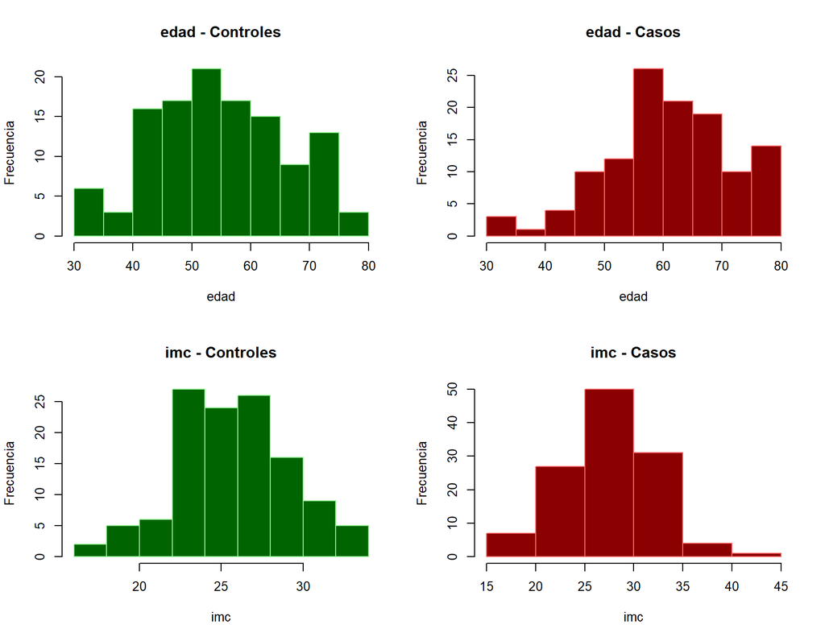

```r
op <- par(mfrow = c(length(variables_cuantitativas), 2))

for (v in variables_cuantitativas) {

  x_control <- datos[[v]][datos$cancer_colorrectal == "Control"]
  x_caso <- datos[[v]][datos$cancer_colorrectal == "Caso"]

  hist(
    x_control,
    main = paste(v, "- Controles"),
    xlab = v,
    ylab = "Frecuencia",
    col = "darkgreen",
    border = "lightgreen"
  )

  hist(
    x_caso,
    main = paste(v, "- Casos"),
    xlab = v,
    ylab = "Frecuencia",
    col = "darkred",
    border = "indianred1"
  )
}
```

```r
par(op)
```

En cuanto a la edad, se observa que los controles presentan una distribución centrada aproximadamente entre los 45 y los 65 años, con una mayor frecuencia en torno a los 50-55 años. En los casos, la distribución aparece desplazada hacia edades superiores, con mayor concentración de participantes entre los 55 y los 70 años. Esto sugiere que los casos presentan una edad generalmente más elevada que los controles.

Respecto al IMC, los controles presentan una mayor concentración de valores entre aproximadamente 22 y 28 kg/m². En los casos, la distribución se encuentra desplazada hacia valores algo superiores, con una mayor concentración entre 25 y 30 kg/m². Además, en el grupo de casos se observa un valor extremo elevado, cercano a 41 kg/m², que alarga la cola derecha de la distribución.

Estos histogramas sugieren que tanto la edad como el IMC presentan valores centrales superiores en los casos que en los controles.

#### 3.1.2.2 Diagramas de caja

Los diagramas de caja permiten comparar la mediana, la dispersión y la presencia de posibles valores atípicos de la edad y del IMC entre casos y controles.

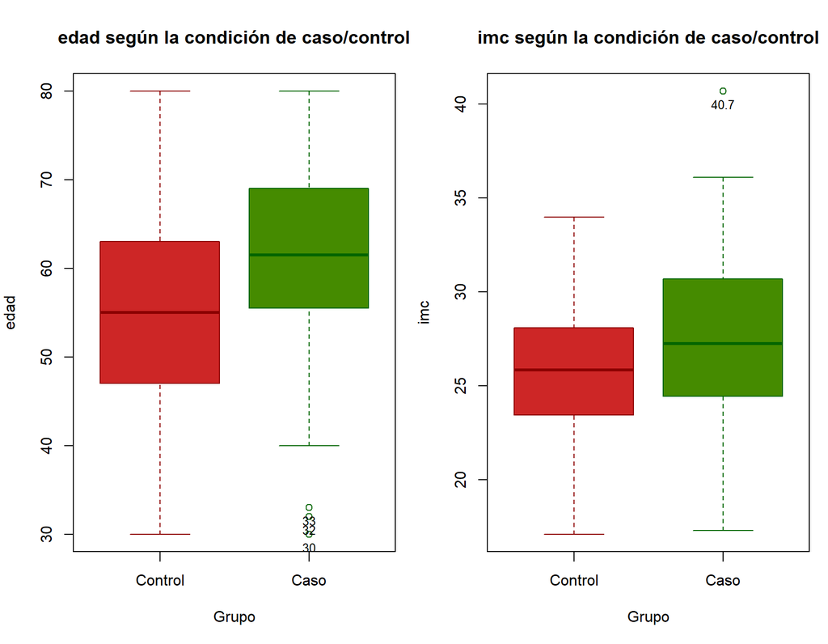

```r
op <- par(mfrow = c(1, length(variables_cuantitativas)),
          mar = c(5, 4, 4, 1))

for (v in variables_cuantitativas) {
  b <- boxplot(
    datos[[v]] ~ datos$cancer_colorrectal,
    main = paste(v, "según la condición de caso/control"),
    xlab = "Grupo",
    ylab = v,
    col = c("firebrick3", "chartreuse4"),
    border = c("darkred", "darkgreen")
  )

  # Etiquetar cada valor atípico (outlier) con su valor, justo debajo del punto.
  if (length(b$out) > 0) {
    text(x = b$group, y = b$out, labels = b$out, pos = 1, cex = 0.8)
  }
}
```

```r
par(op)
```

En relación con la edad, la mediana es superior en los casos. La caja de los casos también se sitúa a edades más elevadas, lo que indica que la distribución de la edad está desplazada hacia valores superiores. Se observan algunos valores atípicos en el extremo inferior del grupo de casos, correspondientes a participantes de menor edad.

En cuanto al IMC, los casos presentan una mediana superior a la de los controles. Además, la caja de los casos es más amplia, lo que indica una mayor dispersión del 50% central de sus valores. Destaca también un valor atípico (outlier) elevado a 40,7 kg/m², en el grupo de casos.

En conjunto, los diagramas de caja respaldan lo observado en los histogramas: los casos presentan valores centrales superiores tanto de edad como de IMC. Además, el IMC muestra una mayor dispersión en los casos y presenta un posible outlier que conviene tener en cuenta al interpretar los resultados. Estas diferencias visuales no determinan por sí solas la significación estadística de las comparaciones. Para evaluar si las medias difieren significativamente, se aplicará una prueba estadística.

#### 3.1.2.3 Gráficos Q-Q

Se elaboran gráficos Q-Q de la edad y del IMC por separado para casos y controles con el fin de evaluar visualmente la aproximación de las distribuciones a la normalidad.

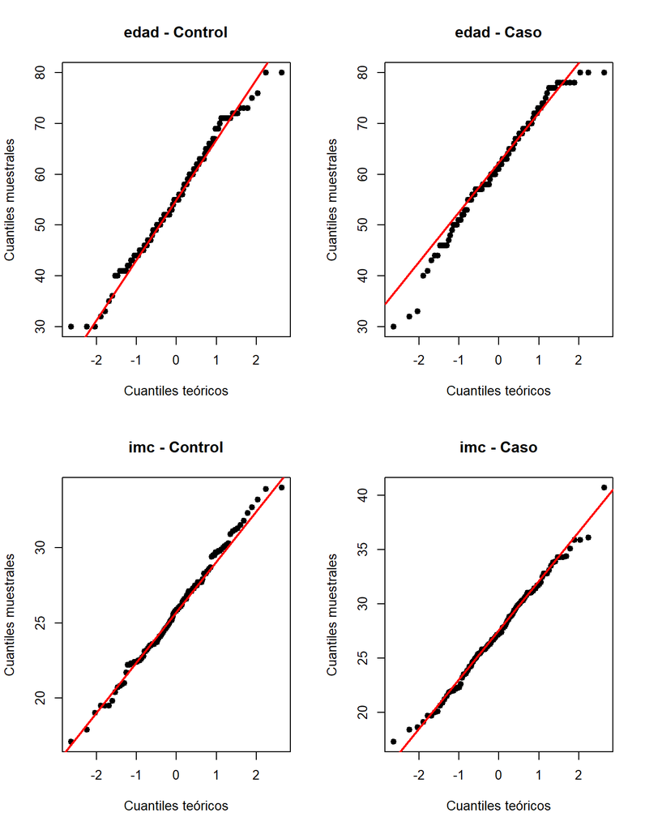

```r
op <- par(mfrow = c(2, 2))

# Comprobar visualmente la normalidad en cada grupo.

for (v in variables_cuantitativas) {
  for (grupo in levels(datos$cancer_colorrectal)) {
    # Seleccionar los valores de la variable en cada grupo.
    x <- datos[[v]][datos$cancer_colorrectal == grupo]
    x <- x[!is.na(x)]
    # Gráfico Q-Q.
    qqnorm(
      x,
      main = paste(v, "-", grupo),
      xlab = "Cuantiles teóricos",
      ylab = "Cuantiles muestrales",
      pch = 19
    )
    # Añadir la línea de referencia.
    qqline(x, col = "red", lwd = 2)
  }
}
```

```r
par(op)
```

Se observa que los puntos del IMC, tanto en los controles como en los casos, siguen bastante bien la línea de referencia, aunque en el grupo de casos destaca una observación en el extremo superior que se aleja de dicha línea. Esto sugiere que ambas distribuciones presentan una aproximación razonable a la normalidad, con una posible desviación en la cola superior del IMC en los casos.

En cuanto a la edad, los puntos se ajustan razonablemente a la línea de referencia en el grupo de controles, aunque se aprecian algunas desviaciones en los extremos. En el grupo de casos, las desviaciones son más visibles, tanto en la cola inferior como en los valores más altos.

En conjunto, los gráficos sugieren que la normalidad se aproxima mejor para el IMC que para la edad.

### 3.1.3 Descripción de variables cualitativas

#### 3.1.3.1 Tabla descriptiva

A continuación se presentan las frecuencias absolutas y los porcentajes de las variables cualitativas, diferenciando entre los grupos de casos y controles de cáncer colorrectal. Los porcentajes se calculan por columnas.

Esta descripción permite comparar la distribución del sexo, el nivel de actividad física, el tabaquismo y los antecedentes familiares entre los participantes con cáncer colorrectal y el grupo control.

```r
subset(datos,select=variables_cualitativas) %>%
  tbl_summary(
    by = cancer_colorrectal,
    type = all_categorical() ~ "categorical",
    statistic = all_categorical() ~ "{n} ({p}%)",
    percent = "column",
    missing = "no",
    label = list(
      sexo ~ "Sexo",
      actividad_fisica ~ "Nivel de actividad física",
      fumador ~ "Tabaquismo",
      antecedentes_familiares ~ "Antecedentes familiares"
    ),
  ) %>%
  add_overall()
```

| **Characteristic** | **Overall** N = 240<sup>1</sup> | **Control** N = 120<sup>1</sup> | **Caso** N = 120<sup>1</sup> |
| --- | --- | --- | --- |
| Sexo |  |  |  |
| Hombre | 113 (47%) | 60 (50%) | 53 (44%) |
| Mujer | 127 (53%) | 60 (50%) | 67 (56%) |
| Nivel de actividad física |  |  |  |
| Alta | 166 (69%) | 91 (76%) | 75 (63%) |
| Baja | 74 (31%) | 29 (24%) | 45 (38%) |
| Tabaquismo |  |  |  |
| No | 166 (69%) | 92 (77%) | 74 (62%) |
| Si | 74 (31%) | 28 (23%) | 46 (38%) |
| Antecedentes familiares |  |  |  |
| No | 174 (73%) | 95 (79%) | 79 (66%) |
| Si | 66 (28%) | 25 (21%) | 41 (34%) |

<sup>1</sup> n (%)

#### 3.1.3.2 Tablas de contingencia y distribución porcentual

Se construyen tablas de contingencia entre la condición de caso/control y cada una de las variables cualitativas estudiadas. Estas tablas muestran las frecuencias observadas y las proporciones por filas y columnas, lo que permite examinar cómo se distribuyen las categorías de cada variable según la presencia o ausencia de cáncer colorrectal.

La comparación de estas distribuciones permite identificar diferencias descriptivas entre casos y controles. No obstante, las diferencias observadas no implican necesariamente una asociación estadísticamente significativa, por lo que se requieren las pruebas de contraste correspondientes para evaluar dicha asociación.

Se excluye la variable de cáncer colorrectal de la lista de variables cualitativas.

```r
for (v in setdiff(variables_cualitativas, "cancer_colorrectal")) {
  cat("\nVariable:", v, "\n")

  gmodels::CrossTable(
    datos$cancer_colorrectal,
    datos[[v]],
    prop.r = TRUE,
    prop.c = TRUE,
    prop.chisq = FALSE
  )
}
```

```
##
## Variable: sexo
##
##
##    Cell Contents
## |-------------------------|
## |                       N |
## |           N / Row Total |
## |           N / Col Total |
## |         N / Table Total |
## |-------------------------|
##
##
## Total Observations in Table:  240
##
##
##                          | datos[[v]]
## datos$cancer_colorrectal |    Hombre |     Mujer | Row Total |
## -------------------------|-----------|-----------|-----------|
##                  Control |        60 |        60 |       120 |
##                          |     0.500 |     0.500 |     0.500 |
##                          |     0.531 |     0.472 |           |
##                          |     0.250 |     0.250 |           |
## -------------------------|-----------|-----------|-----------|
##                     Caso |        53 |        67 |       120 |
##                          |     0.442 |     0.558 |     0.500 |
##                          |     0.469 |     0.528 |           |
##                          |     0.221 |     0.279 |           |
## -------------------------|-----------|-----------|-----------|
##             Column Total |       113 |       127 |       240 |
##                          |     0.471 |     0.529 |           |
## -------------------------|-----------|-----------|-----------|
##
##
##
## Variable: actividad_fisica
##
##
##    Cell Contents
## |-------------------------|
```

[output cut: 81 more lines]

```
##                  Control |        95 |        25 |       120 |
##                          |     0.792 |     0.208 |     0.500 |
##                          |     0.546 |     0.379 |           |
##                          |     0.396 |     0.104 |           |
## -------------------------|-----------|-----------|-----------|
##                     Caso |        79 |        41 |       120 |
##                          |     0.658 |     0.342 |     0.500 |
##                          |     0.454 |     0.621 |           |
##                          |     0.329 |     0.171 |           |
## -------------------------|-----------|-----------|-----------|
##             Column Total |       174 |        66 |       240 |
##                          |     0.725 |     0.275 |           |
## -------------------------|-----------|-----------|-----------|
##
##
```

### 3.1.4 Gráficos descriptivos de variables cualitativas

#### 3.1.4.1 Gráficos de barras

A continuación se muestran los gráficos de barras, que permiten comparar las frecuencias de las variables cualitativas entre los casos de cáncer colorrectal y los controles.

Se excluye la variable de cáncer colorrectal de la lista de variables cualitativas para crear los gráficos de barras sin ella.

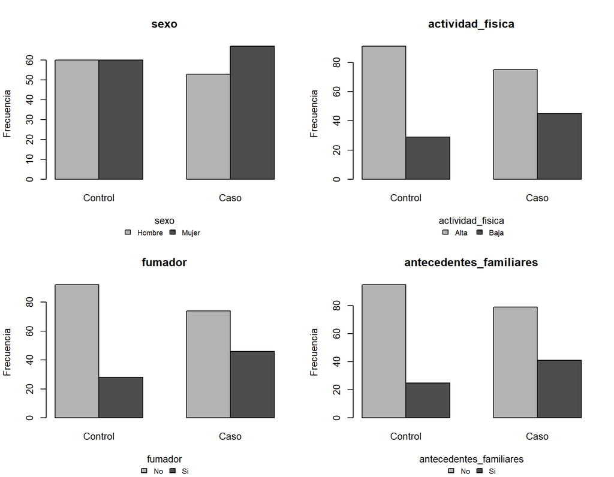

```r
vars_comparar <- setdiff(variables_cualitativas, "cancer_colorrectal")

op <- par(mfrow = c(ceiling(length(vars_comparar) / 2), 2))
for (v in vars_comparar) {

  tabla_grafico <- table(
    datos[[v]],
    datos$cancer_colorrectal
  )

  barplot(
    tabla_grafico,
    beside = TRUE,
    main = paste(v),
    xlab = v,
    ylab = "Frecuencia",
    col = c("grey70", "grey30")
  )
  # Colocar la leyenda debajo del gráfico
  legend(
    "bottom",
    inset = c(0, -0.45),
    legend = rownames(tabla_grafico),
    fill = c("grey70", "grey30"),
    horiz = TRUE,
    xpd = NA,
    bty = "n",
    cex = 0.8
  )
}
```

```r
par(op)
```

En relación con el sexo, la distribución es relativamente similar en ambos grupos. Entre los controles hay 60 hombres y 60 mujeres, mientras que entre los casos hay 53 hombres y 67 mujeres.

Respecto al nivel de actividad física, se observa que la actividad física baja es más frecuente entre los casos (45 participantes) que entre los controles (29 participantes). Por el contrario, la actividad física alta es más frecuente entre los controles (91 participantes) que entre los casos (75 participantes).

En cuanto al tabaquismo, el número de fumadores es superior entre los casos (46) que entre los controles (28).

Por último, los antecedentes familiares de cáncer colorrectal también son más frecuentes entre los casos (41 participantes) que entre los controles (25 participantes).

En conjunto, los gráficos muestran diferencias descriptivas entre casos y controles en el nivel de actividad física, el tabaquismo y los antecedentes familiares, mientras que la distribución por sexo es más similar entre los dos grupos.

### 3.1.5 Respuesta al ejercicio 1

La muestra está formada por 240 participantes: 120 casos de cáncer colorrectal y 120 controles. Cada grupo representa el 50% de la muestra. Esta proporción refleja el diseño de casos y controles y no debe interpretarse como la prevalencia de cáncer colorrectal en la población.

La edad media es de 55,34 años en los controles (con una desviación estándar (DE) de 11,38 años) y de 61,41 años (DE = 10,78) en los casos. Las medianas son 55 y 61,5 años, respectivamente. Descriptivamente, los casos tienen mayor edad y la diferencia entre las medias es de aproximadamente 6,07 años.

El IMC medio es de 25,81 (DE = 3,52) en los controles y de 27,44 (DE = 4,47) en los casos. Las medianas son 25,85 y 27,25, respectivamente. Los casos presentan valores medios de IMC algo superiores y mayor variabilidad en esta variable.

Las mujeres representan el 50% de los controles y el 55,8% de los casos, por lo que la distribución por sexo es relativamente similar entre grupos.

La actividad física baja es más frecuente entre los casos (37,5%) que entre los controles (24,2%). En cambio, la actividad física alta es más frecuente entre los controles (75,8%) que entre los casos (62,5%).

La proporción de fumadores es del 23,3% en los controles y del 38,3% en los casos.

Asimismo, los antecedentes familiares están presentes en el 20,8% de los controles y en el 34,2% de los casos.

En esta muestra, los casos presentan mayor edad media e IMC medio, y mayores proporciones de actividad física baja, tabaquismo y antecedentes familiares que los controles. Estas diferencias son descriptivas y por sí solas no permiten afirmar que las asociaciones sean estadísticamente significativas ni establecer causalidad. La evaluación de asociaciones y posibles factores de confusión requiere los análisis inferenciales posteriores.

## 3.2 Ejercicio 2

**Estudie qué variables podrían actuar como factores de confusión en la relación entre actividad física y cáncer colorrectal. Justifique su respuesta a partir de los datos.**

Para estudiar si la edad, el sexo, el IMC, el hábito tabáquico y los antecedentes familiares pueden actuar como factores de confusión en la relación entre actividad física y cáncer colorrectal, se evalúa la asociación de estas variables tanto con la condición de cancer colorrectal (caso/control) como con el nivel de actividad física, mediante comparaciones estadísticas. Los resultados permiten identificar qué variables merecen una consideración especial en el análisis, aunque estas comparaciones por sí solas no confirman ni descartan definitivamente la existencia de confusión.

### 3.2.1 Tablas estadísticas según el cáncer colorrectal

Se evalúa si estas variables presentan diferencias estadísticamente significativas según el grupo de cáncer colorrectal y si pueden ser factores de confusión. Se analizan por separado las variables cuantitativas y las cualitativas.

#### 3.2.1.1 Variables cuantitativas

Se construye una tabla con `tbl_summary()` para describir las variables cuantitativas según la condición de caso/control de cáncer colorrectal y se añaden dos pruebas para comparar los grupos: una basada en las medias y otra en los rangos.

Primero se emplea la prueba t de Welch para comparar las medias, que no requiere asumir varianzas iguales.

```r
subset(datos,select=variables_cuantitativas_grupo) %>%
  tbl_summary(
    by = cancer_colorrectal,
    statistic = all_continuous() ~ "{mean}",
    label = list(
      edad ~ "Edad (años)",
      imc ~ "Índice de masa corporal (IMC)"
      )
    )%>%
  add_overall()%>%
  add_ci(pattern = "{stat} ({ci})")%>%
  add_p(test = everything() ~ "t.test")
```

| **Characteristic** | **Overall** N = 240 (**95% CI**)<sup>1</sup> | **Control** N = 120 (**95% CI**)<sup>1</sup> | **Caso** N = 120 (**95% CI**)<sup>1</sup> | **p-value**<sup>2</sup> |
| --- | --- | --- | --- | --- |
| Edad (años) | 58 (57, 60) | 55 (53, 57) | 61 (59, 63) | <0.001 |
| Índice de masa corporal (IMC) | 26.6 (26, 27) | 25.8 (25, 26) | 27.4 (27, 28) | 0.002 |

<sup>1</sup> Mean  
<sup>2</sup> Welch Two Sample t-test  
Abbreviation: CI = Confidence Interval

Como análisis complementario, se emplea la prueba de Wilcoxon-Mann-Whitney (`wilcox.test`) para comparar las distribuciones mediante rangos.

```r
subset(datos,select=variables_cuantitativas_grupo) %>%
  tbl_summary(
    by = cancer_colorrectal,
    statistic = all_continuous() ~
      "{median} ({p25}, {p75})",
    label = list(
      edad ~ "Edad (años)",
      imc ~ "Índice de masa corporal (IMC)"
    ),
    digits = all_continuous() ~ 2,
    missing = "no"
  ) %>%
  add_overall() %>%
  add_p(
    test = all_continuous() ~ "wilcox.test"
  )
```

| **Characteristic** | **Overall** N = 240<sup>1</sup> | **Control** N = 120<sup>1</sup> | **Caso** N = 120<sup>1</sup> | **p-value**<sup>2</sup> |
| --- | --- | --- | --- | --- |
| Edad (años) | 58.00 (50.50, 67.00) | 55.00 (47.00, 63.00) | 61.50 (55.50, 69.00) | <0.001 |
| Índice de masa corporal (IMC) | 26.55 (23.65, 29.60) | 25.85 (23.45, 28.10) | 27.25 (24.45, 30.70) | 0.003 |

<sup>1</sup> Median (Q1, Q3)  
<sup>2</sup> Wilcoxon rank sum test

Al aplicar ambas pruebas, se observan diferencias estadísticamente significativas (p < 0,05) en la edad y el IMC entre los grupos de casos y controles de cáncer colorrectal. Estos resultados justifican explorar el papel de ambas variables como posibles factores de confusión.

#### 3.2.1.2 Variables cualitativas

Se construye una tabla con `tbl_summary()` para describir las variables cualitativas según la condición de caso/control de cáncer colorrectal y se añade una prueba para comparar los grupos mediante la prueba de chi-cuadrado de Pearson:

```r
subset(datos,select=variables_cualitativas) %>%
  tbl_summary(
    by = cancer_colorrectal,
    statistic = all_categorical() ~ "{n} ({p}%)",
    percent = "column",
    missing = "no",
    label = list(
      sexo ~ "Sexo",
      actividad_fisica ~ "Nivel de actividad física",
      fumador ~ "Tabaquismo",
      antecedentes_familiares ~ "Antecedentes familiares"
    )
  ) %>%
  add_overall()%>%
  add_p()
```

| **Characteristic** | **Overall** N = 240<sup>1</sup> | **Control** N = 120<sup>1</sup> | **Caso** N = 120<sup>1</sup> | **p-value**<sup>2</sup> |
| --- | --- | --- | --- | --- |
| Sexo |  |  |  | 0.4 |
| Hombre | 113 (47%) | 60 (50%) | 53 (44%) |  |
| Mujer | 127 (53%) | 60 (50%) | 67 (56%) |  |
| Nivel de actividad física |  |  |  | 0.025 |
| Alta | 166 (69%) | 91 (76%) | 75 (63%) |  |
| Baja | 74 (31%) | 29 (24%) | 45 (38%) |  |
| Tabaquismo |  |  |  | 0.012 |
| No | 166 (69%) | 92 (77%) | 74 (62%) |  |
| Si | 74 (31%) | 28 (23%) | 46 (38%) |  |
| Antecedentes familiares |  |  |  | 0.021 |
| No | 174 (73%) | 95 (79%) | 79 (66%) |  |
| Si | 66 (28%) | 25 (21%) | 41 (34%) |  |

<sup>1</sup> n (%)  
<sup>2</sup> Pearson’s Chi-squared test

El sexo no presenta diferencias estadísticamente significativas entre los grupos, mientras que la actividad física, el tabaquismo y los antecedentes familiares presentan valores p inferiores a 0,05.

La actividad física es la exposición de interés del estudio. El tabaquismo y los antecedentes familiares presentan diferencias estadísticamente significativas entre los casos y los controles, mientras que el sexo no muestra diferencias significativas. Estas asociaciones justifican explorar el posible papel de las variables como factores de confusión, pero no bastan por sí solas para establecerlo.

### 3.2.2 Tablas estadísticas según la actividad física

#### 3.2.2.1 Edad e IMC: comparación por actividad física

Se elaboran tablas estadísticas de las variables cuantitativas según la actividad física. Se emplean dos pruebas, como antes.

Primero, se aplica la prueba t:

```r
variables_cuantitativas_af <- c(
  setdiff(names(datos)[sapply(datos, is.numeric)], "id"),
  "actividad_fisica"
)
subset(datos,select=variables_cuantitativas_af) %>%
  tbl_summary(
    by = actividad_fisica,
    statistic = all_continuous() ~ "{mean}",
    label = list(
      edad ~ "Edad (años)",
      imc ~ "Índice de masa corporal (IMC)"
      )
    )%>%
  add_overall()%>%
  add_ci(pattern = "{stat} ({ci})")%>%
  add_p(test = everything() ~ "t.test")
```

| **Characteristic** | **Overall** N = 240 (**95% CI**)<sup>1</sup> | **Alta** N = 166 (**95% CI**)<sup>1</sup> | **Baja** N = 74 (**95% CI**)<sup>1</sup> | **p-value**<sup>2</sup> |
| --- | --- | --- | --- | --- |
| Edad (años) | 58 (57, 60) | 57 (55, 59) | 62 (59, 64) | 0.002 |
| Índice de masa corporal (IMC) | 26.6 (26, 27) | 26.8 (26, 27) | 26.2 (25, 27) | 0.2 |

<sup>1</sup> Mean  
<sup>2</sup> Welch Two Sample t-test  
Abbreviation: CI = Confidence Interval

A continuación, se aplica la prueba de Wilcoxon-Mann-Whitney:

```r
variables_cuantitativas_af <- c(
  setdiff(names(datos)[sapply(datos, is.numeric)], "id"),
  "actividad_fisica"
)
subset(datos,select=variables_cuantitativas_af) %>%
  tbl_summary(
    by = actividad_fisica,
    statistic = all_continuous() ~
      "{median} ({p25}, {p75})",
    label = list(
      edad ~ "Edad (años)",
      imc ~ "Índice de masa corporal (IMC)"
    ),
    digits = all_continuous() ~ 2,
    missing = "no"
  ) %>%
  add_overall() %>%
  add_p(
    test = all_continuous() ~ "wilcox.test"
  )
```

| **Characteristic** | **Overall** N = 240<sup>1</sup> | **Alta** N = 166<sup>1</sup> | **Baja** N = 74<sup>1</sup> | **p-value**<sup>2</sup> |
| --- | --- | --- | --- | --- |
| Edad (años) | 58.00 (50.50, 67.00) | 57.50 (49.00, 65.00) | 60.50 (55.00, 71.00) | 0.005 |
| Índice de masa corporal (IMC) | 26.55 (23.65, 29.60) | 26.70 (23.70, 29.80) | 26.15 (23.50, 29.00) | 0.3 |

<sup>1</sup> Median (Q1, Q3)  
<sup>2</sup> Wilcoxon rank sum test

Se observa que, en este caso, la edad está estadísticamente relacionada con la actividad física, mientras que el IMC no.

#### 3.2.2.2 Sexo, tabaquismo y antecedentes familiares: comparación por actividad física

Se construye una tabla con `tbl_summary()` para describir las variables cualitativas según la actividad física y se añade una prueba para comparar los grupos mediante la prueba de chi-cuadrado de Pearson:

```r
subset(datos, select = variables_cualitativas[variables_cualitativas != "cancer_colorrectal"]) %>%
  tbl_summary(
    by = actividad_fisica,
    statistic = all_categorical() ~ "{n} ({p}%)",
    percent = "column",
    missing = "no",
    label = list(
      sexo ~ "Sexo",
      fumador ~ "Tabaquismo",
      antecedentes_familiares ~ "Antecedentes familiares"
    )
  ) %>%
  add_overall()%>%
  add_p()
```

| **Characteristic** | **Overall** N = 240<sup>1</sup> | **Alta** N = 166<sup>1</sup> | **Baja** N = 74<sup>1</sup> | **p-value**<sup>2</sup> |
| --- | --- | --- | --- | --- |
| Sexo |  |  |  | 0.5 |
| Hombre | 113 (47%) | 76 (46%) | 37 (50%) |  |
| Mujer | 127 (53%) | 90 (54%) | 37 (50%) |  |
| Tabaquismo |  |  |  | 0.3 |
| No | 166 (69%) | 118 (71%) | 48 (65%) |  |
| Si | 74 (31%) | 48 (29%) | 26 (35%) |  |
| Antecedentes familiares |  |  |  | 0.8 |
| No | 174 (73%) | 121 (73%) | 53 (72%) |  |
| Si | 66 (28%) | 45 (27%) | 21 (28%) |  |

<sup>1</sup> n (%)  
<sup>2</sup> Pearson’s Chi-squared test

No se observa una asociación estadísticamente significativa entre estas variables y la actividad física.

### 3.2.3 Conclusiones

En el análisis descriptivo, los casos de cáncer colorrectal presentan una edad media superior a la de los controles (61,41 frente a 55,34 años). Asimismo, la edad media es superior entre las personas con actividad física baja respecto a aquellas con actividad física alta (61,72 frente a 56,89 años). Ambas diferencias son estadísticamente significativas. Por tanto, la edad es la principal candidata a factor de confusión entre las variables examinadas.

El IMC también presenta diferencias estadísticamente significativas entre casos y controles, pero no se encuentra evidencia estadísticamente significativa de una asociación con el nivel de actividad física. El tabaquismo y los antecedentes familiares muestran diferencias entre casos y controles, pero tampoco se observan asociaciones estadísticamente significativas con la actividad física.

En cuanto al sexo, no se encuentran diferencias estadísticamente significativas en las comparaciones realizadas.

En conjunto, la edad es la principal candidata a factor de confusión porque presenta diferencias estadísticamente significativas tanto entre los casos y los controles como entre las personas con actividad física alta y baja.

Estos resultados permiten priorizar la edad para el análisis posterior, aunque las comparaciones bivariantes no permiten confirmar ni descartar por sí solas la existencia de confusión.

# 4 Análisis de regresión

## 4.1 Ejercicio 1

**Estime mediante regresión logística el efecto crudo de un nivel bajo de actividad física sobre el cáncer colorrectal. Exprese el resultado mediante la odds ratio (OR), su intervalo de confianza del 95 % y el valor p.**

### 4.1.1 Regresión logística

Se consideran las siguientes variables:

- **Variable de respuesta**: cáncer colorrectal (`cancer_colorrectal`), codificada como caso frente a control.
- **Variable explicativa**: nivel de actividad física (`actividad_fisica`), con la que se compara la actividad baja frente a la actividad alta.

Se comienza con una regresión logística cruda, sin ajustar por otras variables:

```r
modelo_crudo <- glm(
  cancer_colorrectal ~ actividad_fisica,
  data = datos,
  family = binomial
)
summary(modelo_crudo)
```

```
##
## Call:
## glm(formula = cancer_colorrectal ~ actividad_fisica, family = binomial,
##     data = datos)
##
## Coefficients:
##                      Estimate Std. Error z value Pr(>|z|)
## (Intercept)           -0.1934     0.1560  -1.240   0.2150
## actividad_fisicaBaja   0.6327     0.2847   2.223   0.0262 *
## ---
## Signif. codes:  0 '***' 0.001 '**' 0.01 '*' 0.05 '.' 0.1 ' ' 1
##
## (Dispersion parameter for binomial family taken to be 1)
##
##     Null deviance: 332.71  on 239  degrees of freedom
## Residual deviance: 327.68  on 238  degrees of freedom
## AIC: 331.68
##
## Number of Fisher Scoring iterations: 4
```

A continuación, se calculan las odds ratios:

```r
# Odds ratio e intervalos de confianza del 95 %
exp(cbind(
  OR = coef(modelo_crudo),
  confint(modelo_crudo)
))
```

```
##                             OR     2.5 %   97.5 %
## (Intercept)          0.8241758 0.6058355 1.117831
## actividad_fisicaBaja 1.8827586 1.0826640 3.313624
```

### 4.1.2 Conclusión

Se estima mediante regresión logística la asociación entre un nivel bajo de actividad física y la presencia de cáncer colorrectal, tomando como categoría de referencia la actividad física alta.

Los resultados muestran que las personas con un nivel bajo de actividad física presentan una OR cruda de 1,88 (IC del 95 %: 1,08–3,31; p = 0,026).

Los resultados indican que las odds de presentar cáncer colorrectal entre las personas con un nivel bajo de actividad física son casi el doble que entre las personas con un nivel alto de actividad física. Esta asociación es estadísticamente significativa (OR = 1,88; IC del 95 %: 1,08–3,31; p = 0,026). Dado que el intervalo de confianza del 95 % no incluye el valor 1 y que el valor p es inferior a 0,05, se observa una asociación estadísticamente significativa entre la actividad física baja y el cáncer colorrectal.

Al tratarse de un estudio de casos y controles, estos resultados describen una asociación en términos de odds y no permiten afirmar por sí solos que la baja actividad física sea la causa del cáncer colorrectal.

## 4.2 Ejercicio 2

**Ajuste el modelo por el/los potencial/es factor/es de confusión identificado/s y vuelva a estimar el efecto de la actividad física.**

Para el análisis **principal**, se ajusta el modelo de regresión logística **por edad**, que es la principal candidata a factor de confusión según los resultados del análisis descriptivo. Como **análisis complementarios**, se ajustan modelos separados **por IMC, tabaquismo y antecedentes familiares** para evaluar cuánto cambia la OR al incluir cada variable. El sexo no se incluye en estos modelos individuales porque no se observaron diferencias estadísticamente significativas en las comparaciones exploratorias. No obstante, sí se incluye en el modelo completo del ejercicio 4, tal como solicita el enunciado.

```r
# Posibles factores de confusión
posibles_confusores <- c(
  "edad",
  "imc",
  "fumador",
  "antecedentes_familiares"
)

# Ajustar un modelo por cada posible factor de confusión
for (v in posibles_confusores) {
  cat("\nVariable:", v, "\n")

  formula_modelo <- as.formula(
    paste("cancer_colorrectal ~ actividad_fisica +", v)
  )

  modelo <- glm(
    formula_modelo,
    data = datos,
    family = binomial
  )
  print(summary(modelo))

  # Calcular OR
  print(exp(cbind(OR=coef(modelo), confint(modelo))))
}
```

```
##
## Variable: edad
##
## Call:
## glm(formula = formula_modelo, family = binomial, data = datos)
##
## Coefficients:
##                      Estimate Std. Error z value Pr(>|z|)
## (Intercept)          -2.84748    0.74316  -3.832 0.000127 ***
## actividad_fisicaBaja  0.44816    0.29571   1.516 0.129640
## edad                  0.04638    0.01260   3.681 0.000232 ***
## ---
## Signif. codes:  0 '***' 0.001 '**' 0.01 '*' 0.05 '.' 0.1 ' ' 1
##
## (Dispersion parameter for binomial family taken to be 1)
##
##     Null deviance: 332.71  on 239  degrees of freedom
## Residual deviance: 313.00  on 237  degrees of freedom
## AIC: 319
##
## Number of Fisher Scoring iterations: 4
```

```
##                              OR      2.5 %    97.5 %
## (Intercept)          0.05799042 0.01288501 0.2396289
## actividad_fisicaBaja 1.56542409 0.87857059 2.8090551
## edad                 1.04747628 1.02251364 1.0744633
##
## Variable: imc
##
## Call:
## glm(formula = formula_modelo, family = binomial, data = datos)
##
## Coefficients:
##                      Estimate Std. Error z value Pr(>|z|)
## (Intercept)           -3.1563     0.9327  -3.384 0.000714 ***
## actividad_fisicaBaja   0.7343     0.2938   2.500 0.012437 *
## imc                    0.1102     0.0341   3.231 0.001234 **
## ---
## Signif. codes:  0 '***' 0.001 '**' 0.01 '*' 0.05 '.' 0.1 ' ' 1
##
## (Dispersion parameter for binomial family taken to be 1)
##
##     Null deviance: 332.71  on 239  degrees of freedom
## Residual deviance: 316.55  on 237  degrees of freedom
## AIC: 322.55
##
## Number of Fisher Scoring iterations: 4
```

```
##                              OR       2.5 %    97.5 %
## (Intercept)          0.04258134 0.006494615 0.2545348
## actividad_fisicaBaja 2.08404639 1.179118265 3.7412704
## imc                  1.11645672 1.045766791 1.1958615
##
## Variable: fumador
##
## Call:
## glm(formula = formula_modelo, family = binomial, data = datos)
##
## Coefficients:
##                      Estimate Std. Error z value Pr(>|z|)
## (Intercept)           -0.3953     0.1791  -2.208   0.0273 *
## actividad_fisicaBaja   0.6055     0.2882   2.101   0.0356 *
## fumadorSi              0.6902     0.2888   2.390   0.0168 *
## ---
## Signif. codes:  0 '***' 0.001 '**' 0.01 '*' 0.05 '.' 0.1 ' ' 1
##
## (Dispersion parameter for binomial family taken to be 1)
##
##     Null deviance: 332.71  on 239  degrees of freedom
## Residual deviance: 321.85  on 237  degrees of freedom
## AIC: 327.85
##
## Number of Fisher Scoring iterations: 4
```

```
##                             OR     2.5 %    97.5 %
## (Intercept)          0.6734481 0.4718743 0.9537557
## actividad_fisicaBaja 1.8322402 1.0458428 3.2460947
## fumadorSi            1.9941551 1.1379175 3.5404768
##
## Variable: antecedentes_familiares
##
## Call:
## glm(formula = formula_modelo, family = binomial, data = datos)
##
## Coefficients:
##                           Estimate Std. Error z value Pr(>|z|)
## (Intercept)                -0.3811     0.1777  -2.144   0.0320 *
## actividad_fisicaBaja        0.6384     0.2879   2.218   0.0266 *
## antecedentes_familiaresSi   0.6848     0.2990   2.290   0.0220 *
## ---
## Signif. codes:  0 '***' 0.001 '**' 0.01 '*' 0.05 '.' 0.1 ' ' 1
##
## (Dispersion parameter for binomial family taken to be 1)
##
##     Null deviance: 332.71  on 239  degrees of freedom
## Residual deviance: 322.31  on 237  degrees of freedom
## AIC: 328.31
##
## Number of Fisher Scoring iterations: 4
```

```
##                                  OR     2.5 %    97.5 %
## (Intercept)               0.6831204 0.4799707 0.9650008
## actividad_fisicaBaja      1.8933810 1.0820102 3.3538296
## antecedentes_familiaresSi 1.9832851 1.1104010 3.5985004
```

## 4.3 Ejercicio 3

**Compare e interprete las estimaciones cruda y ajustada. Indique si los resultados son compatibles con la presencia de confusión.**

Ajustando un modelo de regresión logística por separado para cada uno de los posibles factores de confusión identificados en el análisis descriptivo, se observan diferencias según la variable de ajuste en comparación con la OR cruda del primer ejercicio (OR = 1,88; IC del 95 %: 1,08–3,31; p = 0,026).

*Al ajustar por edad*, la OR disminuye de 1,88 a 1,57 y deja de ser estadísticamente significativa (p = 0,130). Este cambio es compatible con que la edad pueda actuar como factor de confusión en la asociación estudiada. Además, la edad se asocia significativamente con el cáncer colorrectal en el modelo ajustado (OR por año = 1,05; p menor que 0,001).

*Al ajustar por IMC*, la OR aumenta hasta 2,08 y la asociación sigue siendo estadísticamente significativa (p = 0,012). Por tanto, el ajuste por IMC no atenúa la asociación observada; en este modelo, la estimación aumenta.

*Al ajustar por tabaquismo*, la OR es de 1,83 y la asociación continúa siendo estadísticamente significativa (p = 0,036). La estimación cambia poco respecto a la OR cruda, por lo que el ajuste por tabaquismo modifica poco la estimación de la asociación en este análisis.

*Al ajustar por antecedentes familiares*, la OR es de 1,89 y también se mantiene la significación estadística (p = 0,027). La estimación es prácticamente igual a la cruda, lo que sugiere que el ajuste por esta variable apenas modifica la asociación observada.

Los resultados muestran que **la edad es la variable que más modifica la estimación de la asociación entre actividad física baja y cáncer colorrectal**. Tras ajustar por edad, la OR disminuye y deja de ser estadísticamente significativa, lo que es compatible con la **presencia de confusión por esta variable**.

En cambio, **el ajuste individual por IMC, tabaquismo o antecedentes familiares apenas atenúa la asociación**.

En cuanto al AIC, el modelo ajustado por edad presenta el valor más bajo (319,00), seguido del modelo ajustado por IMC (322,55), tabaquismo (327,85) y antecedentes familiares (328,31). Esto indica que, entre estos modelos, el ajustado por edad presenta el mejor equilibrio relativo entre ajuste y complejidad según el AIC. Sin embargo, el AIC no confirma por sí solo la existencia de confusión.

## 4.4 Ejercicio 4

**Como análisis adicional, ajuste un modelo que incluya todas las variables recogidas y comente brevemente si la conclusión principal cambia.**

Para ello, se ajusta un modelo de regresión logística multivariable que incluye todas las variables recogidas en el estudio. Después se comprueba si la asociación entre la actividad física baja y el cáncer colorrectal cambia respecto a los modelos anteriores.

```r
# Modelo de regresión logística con todas las variables

# Se establece "Mujer" como primer nivel del factor.
# En la regresión logística, el primer nivel es la categoría de referencia por defecto.
# Por tanto, el efecto estimado para "Hombre" se compara con el de "Mujer".
datos$sexo <- factor(
  datos$sexo,
  levels = c("Mujer", "Hombre")
)

modelo_completo <- glm(
  cancer_colorrectal ~ actividad_fisica + edad + sexo +
    imc + fumador + antecedentes_familiares,
  data = datos,
  family = binomial
)

# Resumen del modelo
summary(modelo_completo)
```

```
##
## Call:
## glm(formula = cancer_colorrectal ~ actividad_fisica + edad +
##     sexo + imc + fumador + antecedentes_familiares, family = binomial,
##     data = datos)
##
## Coefficients:
##                           Estimate Std. Error z value Pr(>|z|)
## (Intercept)               -5.24247    1.17591  -4.458 8.26e-06 ***
## actividad_fisicaBaja       0.57493    0.31109   1.848  0.06458 .
## edad                       0.03547    0.01332   2.663  0.00775 **
## sexoHombre                -0.29786    0.28054  -1.062  0.28835
## imc                        0.10398    0.03668   2.835  0.00459 **
## fumadorSi                  0.59220    0.30738   1.927  0.05403 .
## antecedentes_familiaresSi  0.69372    0.32007   2.167  0.03020 *
## ---
## Signif. codes:  0 '***' 0.001 '**' 0.01 '*' 0.05 '.' 0.1 ' ' 1
##
## (Dispersion parameter for binomial family taken to be 1)
##
##     Null deviance: 332.71  on 239  degrees of freedom
## Residual deviance: 295.98  on 233  degrees of freedom
## AIC: 309.98
##
## Number of Fisher Scoring iterations: 4
```

```r
# Odds ratios e intervalos de confianza del 95 %
exp(cbind(
  OR = coef(modelo_completo),
  confint(modelo_completo)
))
```

```
##                                    OR        2.5 %     97.5 %
## (Intercept)               0.005287203 0.0004828915 0.04925239
## actividad_fisicaBaja      1.777012528 0.9696002115 3.29428702
## edad                      1.036109054 1.0098399754 1.06417509
## sexoHombre                0.742407804 0.4267210911 1.28457273
## imc                       1.109577270 1.0339673846 1.19444453
## fumadorSi                 1.807970215 0.9933808452 3.32653204
## antecedentes_familiaresSi 2.001153367 1.0757080411 3.78861694
```

Al comparar el modelo completo con el modelo crudo, la OR disminuye ligeramente, de 1,88 a 1,78, aunque la dirección de la asociación se mantiene.

Sin embargo, tras el ajuste, la asociación no alcanza significación estadística al nivel del 5% (IC del 95%: 0,97–3,29; p = 0,065).

Por tanto, la conclusión se mantiene en cuanto a la dirección de la asociación, pero no en cuanto a su significación estadística. Estos resultados no permiten afirmar que no exista asociación, sino que no hay evidencia estadística suficiente para establecerla al nivel de significación considerado.